# Data Challenge - Part1: NLP-Based Composer Classification

**Author**: Emmanuel Ekwedike

**Date**: 08/18/23

## Abstract

In this work, we build a composer classifier based on live captured audio, streaming data to our model every 30 seconds. For this project, Our dataset consists of numerous annotated audio files saved in MIDI format. To represent each musical piece within the MIDI files, we've employed an NLP-based approach. Using the extracted features, we constructed three machine-learning algorithms. Our experiments underscore the model's sensitivity to both feature extraction and data quality. With the present data, our models achieved an impressive F1-score of 0.97 during cross-validation.

## Introduction

Music, a universal language, transcends boundaries and evokes emotions. In the realm of technology and creativity, the fusion of music and machine learning opens doors to new possibilities.

The literature has witnessed endeavors to identify music styles and composers through diverse computational methods. The emergence of statistical machine learning, deep learning, and statistical NLP has been pivotal in unraveling insights into music representation [Wołkowicz2008].

Music's similarity to natural language has opened avenues for employing NLP tools in music analysis. Drawing inspiration from recent successes in NLP-based approaches [Wołkowicz2008], Deepaisarn2023a], we adapted a similar methodology proposed by [Deepaisarn2023a].

The rest of the report is organized as follows: Methodology, Results, Discussion, Conclusion, and Recommendation.

### Preamble

Import helpful libraries

```python
import os
import sys
import gensim
import collections
import numpy as np
import pandas as pd
import seaborn as sns
import sentencepiece as spm
import utils.data_utils as du

# modeling utils
from sklearn import metrics
from sklearn.svm import SVC
from sklearn.metrics import accuracy_score
from sklearn.model_selection import train_test_split
from sklearn.neighbors import KNeighborsClassifier
from sklearn.ensemble import RandomForestClassifier
from sklearn.linear_model import LogisticRegression
from sklearn.preprocessing import StandardScaler, MinMaxScaler

#plotting utils
import matplotlib.pyplot as plt
%matplotlib inline

import warnings
warnings.filterwarnings("ignore")
```

#### Load data and Create Metadata

```python
base_path = "./data/train"
df_metadata, df_num_music_piece, composer_data = du.get_metadata(base_path)
```

## Methodology

The methodology section presents an overview of the experiment, encompassing the Dataset employed, the NLP-driven feature Extraction technique, and the trio of machine learning algorithms utilized.

### Dataset

This study utilized annotated musical data extracted from Musicnet [Thickstun2016], presented in MIDI format. The data comprises MIDI files associated with four composers: Bach, Beethoven, Schubert, and Brahms. These MIDI files encompass extra details, like composition names and instruments, which might not be accessible during inference. Consequently, we'll exclude this supplementary information during algorithm development.

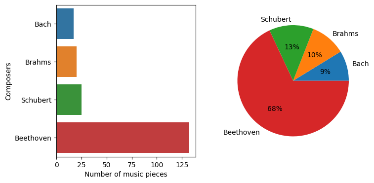

```python
du.plot_composer_dist(df_num_music_piece)
```

Analyzing the distribution of music pieces grouped by composers reveals a notable class imbalance. Beethoven's compositions considerably outnumber those of the other three composers combined. Addressing this imbalance is crucial during model development. Due to the limited dataset of 194 data points, retaining all of Beethoven's compositions is recommended at this stage.

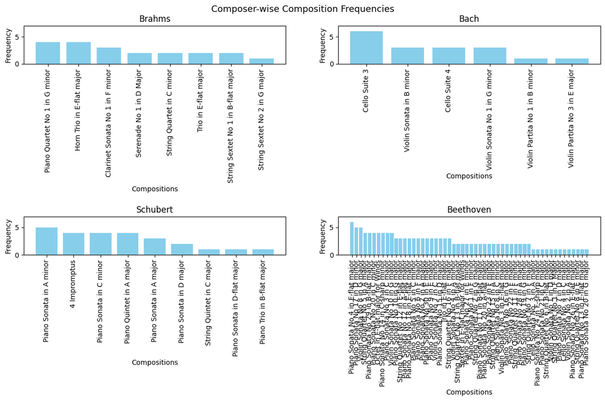

```python
du.plot_freq_composition(composer_data)
```

### NLP-based Feature Extraction

There are six steps according to our implementation of the paper [Deepaisarn2023a]. We leveraged some code from the open sourced code for this paper [Deepaisarn2023b](https://github.com/SirawitC/NLP-based-music-processing-for-composer-classification/blob/main/Musical_AI_Composer_classification_with_NLP_based_approaches.ipynb)

**Step1**: We utilize the 'pretty_midi' Python package [Raffel2014] to extract musical attributes—pitch, duration, start and end times, and note velocity—from MIDI files.

**Step2**: Create note coordinate pairs (P_i, D_i), where P_i is the pitch and D_i is the duration of each note i.

```python
eg_suffix_path = df_metadata["midi_filename"][0]
path_midi_filename = os.path.join(base_path, eg_suffix_path)
df_musical_features  = du.convert_midifiles_to_notes(path_midi_filename)
df_musical_features.head(n=2)
```

|  | pitch | start | end | step | duration | velocity |
| --- | --- | --- | --- | --- | --- | --- |
| 0 | 75 | 2.470587 | 2.647057 | 0.00000 | 0.176470 | 60 |
| 1 | 74 | 2.647057 | 2.999999 | 0.17647 | 0.352941 | 60 |

```python
def extract_Pi_Di_tuple(df_metadata, use_saved_data = False, save_path= "./all_gram_list_note.npy"):
    """
        :param df_metadata:
        :param use_save:
        :param save_path:
        :output all_gram_list, df_metadata_subset: list of all cordinate pairs, and subset of metadata
    """
    if use_saved_data:
        all_gram_list = np.load(save_path)
        corrupt_indices = []
    else:
        all_gram_list = []
        cnt = 0
        corrupt_indices = []
        for i in range(df_metadata.shape[0]):
            suffix_path = df_metadata["midi_filename"][i]
            path = os.path.join(base_path, suffix_path)
            try:
                frame = du.convert_midifiles_to_notes(path)
                gram_list = du.extract_gram(frame)
                all_gram_list = all_gram_list + gram_list
            except:
                corrupt_indices.append(i)
                continue
        np.save(save_path,all_gram_list)
        all_gram_list = np.array(all_gram_list)

    df_metadata_subset = df_metadata.drop(index = corrupt_indices).copy()
    df_metadata_subset.reset_index(inplace=True)
    return all_gram_list, df_metadata_subset
```

```python
all_gram_list, df_metadata_subset = extract_Pi_Di_tuple(df_metadata, use_saved_data = False, save_path= "./all_gram_list_note.npy")
```

**Step3**: Subsequently, we map all tuples to Unicode characters, ensuring identical tuples are represented by the same character.

**Step4**: These Unicode characters are then processed using the SentencePiece algorithm, which groups frequently appearing character sequences into words or subwords. In the context of music, this identifies and consolidates sequences of commonly occurring notes.

```python
def build_corpus(df_metadata_subset, all_gram_list, filename = "corpus.txt"):
    """
        :param df_metadata_subset:
        :param all_gram_list:
        :param filename:
        :output : None
    """
    sorted_gram_list = sorted(set(tuple(i) for i in all_gram_list.tolist()))
    note2Char = { j:du.encodeChinese(i) for i,j in enumerate(sorted_gram_list)}
    Char2note =  { du.encodeChinese(i):j for i,j in enumerate(sorted_gram_list)}

    corpus_text = ''
    for i in range(df_metadata_subset.shape[0]):
        suffix_path = df_metadata_subset["midi_filename"][i]
        path = os.path.join(base_path, suffix_path)
        frame = du.convert_midifiles_to_notes(path)
        gram_list = du.extract_gram(frame)
        for j in gram_list:
          corpus_text += note2Char[j]
        corpus_text += '\n'
    with open(filename, "w") as f:
        f.write(corpus_text)
```

```python
def sentencePiece(corpus, modelName, vocabSize, maxSenLength):
    """
        :param corpus:
        :param modelName:
        :param vocabSize:
        :param maxSenLength:
        :output : sentences
    """
    MAXITER =1276
    spm.SentencePieceTrainer.train(input=corpus, model_prefix=modelName, vocab_size=vocabSize, max_sentence_length=maxSenLength)
    sp = spm.SentencePieceProcessor()
    temp = modelName+".model"
    sp.load(temp)
    f1 = open(corpus,'r')
    temp = {}
    for i in range(MAXITER):
        line = f1.readline()

        tokenized = sp.encode_as_pieces(line)
        temp[i] = tokenized
    Ch_note_series = pd.Series(temp)
    f1.close()
    sentences = []
    for i in range(Ch_note_series.shape[0]):
        sentences.append(Ch_note_series[i])
    return sentences
```

**Step5**: Apply Word2Vec to convert extracted musical words or subwords from the previous step into vectors.

**Step6**: Ultimately, generate a comprehensive music piece vector by concatenating the average and standard deviation of musical word vectors.

```python
def Word2Vec(Window, sentences):
    """
        :param Window:
        :param : sentences
        :output :
    """
    model = gensim.models.Word2Vec(
        sentences=sentences,
        window=Window,
        min_count=1,
        workers=4,
        sg = 1
    )
    sentence_lst_with_avg_and_sd = du.get_sentence_vector_avg_and_sd(sentences,model)
    return sentence_lst_with_avg_and_sd
```

```python
def get_process_features(corpus, modelName, df_metadata_subset, vocabSize = 167, maxSenLength = 64, window = 15):
    """
        :param Window:
        :param modelName:
        :param df_metadata_subset:
        :param vocabSize:
        :param maxSenLength:
        :param window:
        :output X, y, composer_map:
    """

    sentences = sentencePiece(corpus, modelName, vocabSize, maxSenLength)
    sentencesLst = Word2Vec(window, sentences)
    X, y, composer_map = du.create_label(sentencesLst, df_metadata_subset)
    return X, y, composer_map
```

```python
build_corpus(df_metadata_subset, all_gram_list, filename = "corpus.txt")
```

```python
corpus = "corpus.txt"
modelName = "model"
maxSenLength = 64
window = 15
X, y, composer_map= get_process_features(corpus, modelName, df_metadata_subset, vocabSize = 167, maxSenLength = 64, window = 15)
```

[output not shown]

[output cut: 17 more lines]

[output not shown]

```python
composer_map
```

```
{'Bach': 0, 'Beethoven': 1, 'Brahms': 2, 'Schubert': 3}
```

```python
from collections import defaultdict

def get_index_map(y):
    index_map = defaultdict(list)
    for idx, val in enumerate(y):
        index_map[val].append(idx)
    return index_map
```

```python
import random
def get_n_samples_indices(index_map, ksamples):
    full_samples = []
    for k, vlist in index_map.items():
        selected_sample =random.sample(vlist, ksamples)
        # print(selected_sample)
        full_samples.extend(selected_sample)
    return full_samples
```

```python
def get_metric_acc(sample_indices, X, y):
    """
    Calculate performance metrics for classification using different classifiers.

    This function calculates classification metrics such as F1-score for multiple classifiers (K-Nearest Neighbors,
    Random Forest, and Logistic Regression) based on the provided sample indices and data.

    Parameters:
    - sample_indices (list or array): Indices of the samples to use for training the classifiers.
    - X (array-like): Feature matrix of the dataset.
    - y (array-like): Target labels of the dataset.

    Returns:
    - knn_f1_score (float): Weighted F1-score for the K-Nearest Neighbors classifier.
    - rf_f1_score (float): Weighted F1-score for the Random Forest classifier.
    - lr_f1_score (float): Weighted F1-score for the Logistic Regression classifier.
    """
    mask = np.zeros((X.shape[0],1),dtype=bool)
    mask[tuple(sample_indices),:] = True
    y_sub = y.reshape(-1,1)[mask]
    # y_sub = y.reshape(-1,1)[tuple(sample_indices),:]
    y_sub = y_sub.reshape(-1)
    y_sub_test =y.reshape(-1,1)[~mask]
    y_sub_test = y_sub_test.reshape(-1)

    X_sub  = X[mask.reshape(-1)]
    X_sub_test = X[~ mask.reshape(-1)]

    clf_knn = KNeighborsClassifier(n_neighbors=4)
    knn = clf_knn.fit(X_sub,y_sub)

    clf_rf = RandomForestClassifier(max_depth=500, random_state=0)
    rf = clf_rf.fit(X_sub,y_sub)

    clf_lr = LogisticRegression(random_state=0, max_iter=300)
    lr = clf_lr.fit(X_sub,y_sub)

    knn_pred=knn.predict(X_sub_test)
    rf_pred=rf.predict(X_sub_test)
    lr_pred=lr.predict(X_sub_test)
    # knn_acc = accuracy_score(y_sub_test, knn_pred)
    # rf_acc = accuracy_score(y_sub_test, rf_pred)
    # lr_acc = accuracy_score(y_sub_test, lr_pred)
    knn_acc= metrics.f1_score(y_sub_test, knn_pred, average='weighted')
    rf_acc= metrics.f1_score(y_sub_test, rf_pred, average='weighted')
    lr_acc= metrics.f1_score(y_sub_test, lr_pred, average='weighted')
    # print(f"knn: {knn_acc}, rf: {rf_acc} and lr: {lr_acc}")
    return knn_acc, rf_acc, lr_acc
```

### Machine Learning Classification Models

In the following section, we outline the implementation of three classical machine learning models: logistic regression (LR), random forest (RF), and k-nearest neighbors (KNN). These models are employed to classify music samples into four distinct categories, each corresponding to composers Bach, Beethoven, Schubert, and Brahms.

To facilitate experimentation, the processed dataset comprising 184 samples is partitioned into training and testing subsets. The training set is utilized for model training, while the testing set serves for model evaluation. The division ratio between train and test sets is set at 80% and 20% respectively.

To assess the performance of the classifiers, we employ the weighted F1 score as our chosen metric. This selection is motivated by the multi-class nature of the classification task and the need to address data imbalances observed within the dataset. Furthermore, cross-validation results are documented to ensure the reliability and robustness of our chosen evaluation metric.

```python
# Scale features
X, y = np.stack(X), np.stack(y)
PredictorScaler=StandardScaler()
PredictorScalerFit=PredictorScaler.fit(X)
X=PredictorScalerFit.transform(X)
```

#### Cross validataion

```python
def run_random_cross_validation(classifier, X, y, NUM_CV_TRIAL = 100, holdoutratio = 0.2):
    """
    Run random cross-validation for a classifier.

    This function performs random cross-validation for a given classifier on a dataset, assessing its performance
    over multiple trials. It randomly splits the data into training and validation sets for each trial and reports
    evaluation metrics.

    Parameters:
    - classifier: The classifier to be evaluated.
    - X: The feature matrix of the dataset.
    - y: The corresponding target labels.
    - NUM_CV_TRIAL (int): The number of cross-validation trials to run (default is 100).
    - holdout_ratio (float): The ratio of data to hold out for validation in each trial (default is 0.2).

    Returns:
    - mean_accuracy (float): The mean accuracy over all cross-validation trials.
    - mean_precision (float): The mean precision over all cross-validation trials.
    - mean_recall (float): The mean recall over all cross-validation trials.
    - mean_f1_score (float): The mean F1 score over all cross-validation trials.
    """
    print(f"Running Cross validation for model {classifier.__class__.__name__}")
    list_f1_scores = []
    for _ in range(NUM_CV_TRIAL):
        ind = np.arange(len(y))
        np.random.shuffle(ind)
        split = round(len(y) * (1-holdoutratio))
        X_train = X[ind[:split]]
        X_test = X[ind[split:]]
        y_train = y[ind[:split]]
        y_test = y[ind[split:]]
        cls=classifier.fit(X_train,y_train)
        prediction=cls.predict(X_test)
        f1_Score_cls=metrics.f1_score(y_test, prediction, average='weighted')
        list_f1_scores.append(f1_Score_cls)
    avg_f1_score = np.mean(list_f1_scores)
    std_f1_score = np.std(list_f1_scores)
    return avg_f1_score, std_f1_score
```

```python
#KNN
clf_knn = KNeighborsClassifier(n_neighbors=5)
cv_f1_Score_knn, cv_f1_Score_knn_std =run_random_cross_validation(clf_knn, X, y, NUM_CV_TRIAL = 100, holdoutratio = 0.2)

#Random forest
clf_rf = RandomForestClassifier(max_depth=500, random_state=0)
cv_f1_Score_rf, cv_f1_Score_rf_std=run_random_cross_validation(clf_rf, X, y, NUM_CV_TRIAL = 100, holdoutratio = 0.2)

#Logistic regression
clf_lr = LogisticRegression(random_state=0, max_iter=300)
cv_f1_Score_lr, cv_f1_Score_lr_std=run_random_cross_validation(clf_lr, X, y, NUM_CV_TRIAL = 100, holdoutratio = 0.2)
```

```
Running Cross validation for model KNeighborsClassifier
Running Cross validation for model RandomForestClassifier
Running Cross validation for model LogisticRegression
```

### Results and Discussion:

```python
print(f"Cross-validation f1-score (KNN): {cv_f1_Score_knn},   and  cv_std {cv_f1_Score_knn_std}")
print(f"Cross-validation f1-score (RF): {cv_f1_Score_rf},     and  cv_std {cv_f1_Score_rf_std}")
print(f"Cross-validation f1-score (LR): {cv_f1_Score_lr},     and  cv_std {cv_f1_Score_lr_std}")
```

```
Cross-validation f1-score (KNN): 0.9055424726603144,   and  cv_std 0.052545998812472905
Cross-validation f1-score (RF): 0.987897754574603,     and  cv_std 0.015808451371567007
Cross-validation f1-score (LR): 0.9743557511491338,     and  cv_std 0.02693800033258389
```

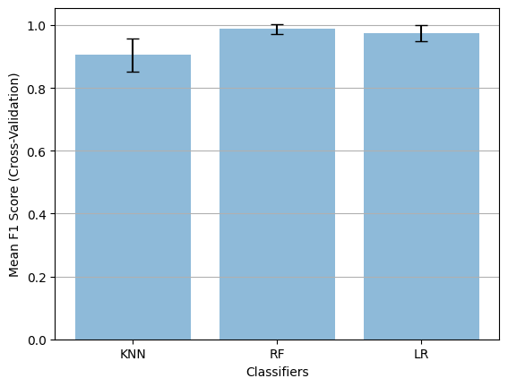

```python
# Create lists for the plot
cls_names = ['KNN', 'RF', 'LR']
x_pos = np.arange(len(cls_names))
AVGs = [cv_f1_Score_knn, cv_f1_Score_rf, cv_f1_Score_lr]
error = [cv_f1_Score_knn_std, cv_f1_Score_rf_std, cv_f1_Score_lr_std]

fig, ax = plt.subplots()
ax.bar(x_pos, AVGs, yerr=error, align='center', alpha=0.5, ecolor='black', capsize=5)
ax.set_ylabel('Mean F1 Score (Cross-Validation)')
ax.set_xlabel('Classifiers')
ax.set_xticks(x_pos)
ax.set_xticklabels(cls_names)
ax.yaxis.grid(True)
```

#### Discussion

We exclusively examined traditional machine learning approach(es) and established a comprehensive pipeline for those methods. Through this, we achieved a remarkable cross-validation result – a weighted F1 score of 0.98 on imbalanced data. Additionally, there is minimal variance among various cross-validation samples. This outcome underscores robust performance.

**Classifier Performance:** The weighted F1 score is a measure that considers both precision and recall, making it a suitable metric for imbalanced datasets. An F1 score of 0.98 indicates that the classifier is able to effectively balance between precision and recall across all classes, resulting in very accurate predictions.

**Balancing Precision and Recall:** F1 score is the harmonic mean of precision and recall. Precision measures the ratio of true positive predictions to the total predicted positives, while recall measures the ratio of true positive predictions to the total actual positives. Achieving a high F1 score indicates that the classifier is successfully balancing the trade-off between making accurate positive predictions (precision) and capturing the actual positives (recall).

**Business Impact**: The strong classifier's performance can bring substantial benefits. For example, in the client's application of identifying compositions beyond the four trained composers, accuracy in classification is crucial. This classifier has the potential to enhance decision-making reliability and accuracy.

#### Final Pipeline for Identification

To identify compositions outside the four classes present in the training set, the following pipeline was used:

```python
def detect_unknown_composer(classifer, X_validation,threshold = 0.55):
    """
    Detect unknown composers using a classifier.

    This function takes a pre-trained classifier and a set of validation data (X_validation) to predict whether the composers
    of the given data are unknown based on a specified threshold.

    Parameters:
    - classifier: A pre-trained composer classifier model.
    - X_validation: Validation data containing features for composer classification.
    - threshold (float): The threshold for deciding if a composer is unknown (default is 0.55).

    Returns:
    - unknown_composers (list): A list of indices corresponding to the data samples with predicted unknown composers.
    - predicted_probabilities (list): A list of predicted probabilities for each data sample.
    """
    val_probabilities = classifer.predict_proba(X_validation)
    print(f"Probabilities of the validation data\n {val_probabilities}")

    # Identify samples not belonging to any class
    index_samples_not_belonging = []
    for i, probabilities in enumerate(val_probabilities):
        if all(p < threshold for p in probabilities):
            index_samples_not_belonging.append(i)

    # Print the indices of samples not belonging to any class
    len_of_outliers = len(index_samples_not_belonging)
    print(f"At threshold {threshold}, the number of sample(s) not belonging to any of the 4 classes: {len_of_outliers}")
    return index_samples_not_belonging
```

#### Test Pipline

```python
def extract_Pi_Di_tuple_test(compositions, use_saved_data = False, save_path= "./all_gram_list_note_test.npy"):
    """
        :param compositions:
        :param use_saved_data:
        :param save_path:
        :output all_gram_list, df_metadata_subset: list of all cordinate pairs, and subset of metadata
    """
    if use_saved_data:
        all_gram_list_test = np.load(save_path)
    else:
        all_gram_list_test = []
        cnt = 0
        for suffix_path in compositions:
            path = os.path.join(test_base_path, suffix_path)
            try:
                frame = du.convert_midifiles_to_notes(path)
                gram_list = du.extract_gram(frame)
                all_gram_list_test = all_gram_list_test + gram_list
            except:
                continue
        np.save(save_path,all_gram_list_test)
        all_gram_list_test = np.array(all_gram_list_test)
    return all_gram_list_test
```

```python
def extract_features_for_validation_data(all_gram_list_test, modelName = "model_val", filename = "corpus_val.txt",    vocabSize = 39, maxSenLength = 10, window = 5):
    """
    Extract features from a list of n-grams for validation data.

    This function takes a list of n-grams, typically generated from validation data, and prepares them for
    feature extraction. It includes options to specify the model name, filename for corpus storage,
    vocabulary size, maximum sentence length, and the context window size.

    Parameters:
    - all_gram_list_test (list): A list of n-grams from validation data.
    - modelName (str): The name for the model to be saved (default is "model_val").
    - filename (str): The name of the file to store the corpus (default is "corpus_val.txt").
    - vocabSize (int): The desired vocabulary size (default is 39).
    - maxSenLength (int): The maximum sentence length (default is 10).
    - window (int): The context window size for feature extraction (default is 5).

    Returns:
    None
    """
    sorted_gram_list = sorted(set(tuple(i) for i in all_gram_list_test.tolist()))
    note2Char = { j:du.encodeChinese(i) for i,j in enumerate(sorted_gram_list)}
    Char2note =  { du.encodeChinese(i):j for i,j in enumerate(sorted_gram_list)}
    text = ''
    for suffix_path in compositions:
        path = os.path.join(test_base_path, suffix_path)
        frame = du.convert_midifiles_to_notes(path)
        gram_list = du.extract_gram(frame)
        for j in gram_list:
          text += note2Char[j]
        text += '\n'
    f = open(filename, "w")
    f.write(text)
    f.close()
    sentences = sentencePiece(corpus=filename, modelName=modelName, vocabSize=vocabSize, maxSenLength=maxSenLength)
    X_validation = Word2Vec(Window=window, sentences=sentences)
    X_validation = X_validation[:len(compositions)].copy()
    return X_validation
```

```python
test_base_path = "./data/test"
compositions = os.listdir(test_base_path)
all_gram_list_test = extract_Pi_Di_tuple_test(compositions, use_saved_data = True, save_path= "./all_gram_list_note_test.npy")
X_validation = extract_features_for_validation_data(all_gram_list_test=all_gram_list_test)
```

[output not shown]

[output cut: 17 more lines]

[output not shown]

```python
#Test with RL classifier which was our best performing classifier

X_validation = np.stack(X_validation)
PredictorScaler=StandardScaler()
PredictorScalerFit=PredictorScaler.fit(X_validation)
X_validation=PredictorScalerFit.transform(X_validation)
index_samples_not_belonging = detect_unknown_composer(classifer=clf_rf, X_validation=X_validation, threshold = 0.45)
print(f"The corresponding indices: {index_samples_not_belonging}")
```

```
Probabilities of the validation data
 [[0.18 0.23 0.24 0.35]
 [0.1  0.37 0.21 0.32]
 [0.11 0.51 0.16 0.22]
 [0.17 0.5  0.1  0.23]
 [0.13 0.59 0.06 0.22]
 [0.09 0.58 0.14 0.19]
 [0.08 0.6  0.09 0.23]
 [0.08 0.65 0.12 0.15]
 [0.1  0.44 0.15 0.31]
 [0.04 0.6  0.08 0.28]
 [0.07 0.74 0.04 0.15]
 [0.12 0.42 0.09 0.37]
 [0.16 0.48 0.09 0.27]
 [0.19 0.4  0.08 0.33]
 [0.21 0.41 0.1  0.28]
 [0.19 0.45 0.1  0.26]
 [0.13 0.46 0.11 0.3 ]
 [0.05 0.5  0.07 0.38]
 [0.08 0.52 0.07 0.33]
 [0.05 0.58 0.06 0.31]
 [0.08 0.49 0.05 0.38]
 [0.13 0.37 0.07 0.43]
 [0.16 0.36 0.04 0.44]
 [0.15 0.41 0.08 0.36]
 [0.16 0.46 0.06 0.32]
 [0.18 0.38 0.07 0.37]
 [0.18 0.42 0.08 0.32]
 [0.19 0.41 0.09 0.31]
 [0.17 0.41 0.07 0.35]
 [0.12 0.45 0.09 0.34]
 [0.19 0.49 0.05 0.27]
 [0.16 0.54 0.04 0.26]
 [0.16 0.52 0.05 0.27]
 [0.16 0.47 0.1  0.27]
 [0.16 0.52 0.09 0.23]]
At threshold 0.45, the number of sample(s) not belonging to any of the 4 classes: 13
The corresponding indices: [0, 1, 8, 11, 13, 14, 21, 22, 23, 25, 26, 27, 28]
```

## Conclusion and Recommendations

In this study, we develop a composer classifier using real-time audio inputs. Our dataset comprises annotated MIDI format audio files. We utilize an NLP-based method for feature extraction, yielding promising results. Our models achieve a notable F1-score of 0.97 in cross-validation experiments.

### Recommendations

Our primary recommendation centers on ensuring robustness.

1. **Data Collection Stage Robustness:** Enhance data collection with a focus on both training and validation data. Enriching the validation set will improve model evaluation accuracy and aid in refining detection thresholds for out-of-sample composers. The training process will benefit from additional data, especially if challenging negative samples are collected to supplement the existing data. Incorporating difficult data and adversarial examples will significantly enhance model robustness. Additionally, address data imbalance during collection to ensure effective learning across all classes.
2. **Evaluation Process Robustness:** Reassess model selection in light of augmented data. Ensemble and deep learning methods offer potential improvements over existing techniques. Consider advanced feature engineering to extract more generalized audio features, thereby enhancing overall evaluation. Regularly enhance the model by monitoring performance, gathering deployment environment feedback, and analyzing how temporal and environmental changes impact model effectiveness.

## References

- [Thickstun2016] Thickstun, John & Harchaoui, Zaid & Kakade, Sham. (2016). Learning Features of Music from Scratch.
- [Deepaisarn2023a] Deepaisarn S, Chokphantavee S, Chokphantavee S, Prathipasen P, Buaruk S, Sornlertlamvanich V. NLP-based music processing for composer classification. Sci Rep. 2023 Aug 14;13(1):13228. doi: 10.1038/s41598-023-40332-0. PMID: 37580364; PMCID: PMC10425398.
- [Deepaisarn2023b] Codebase: https://github.com/SirawitC/NLP-based-music-processing-for-composer-classification
- [Wołkowicz2008] Wołkowicz, J., Kulka, Z. & Kešelj, V. N-gram-based approach to composer recognition. Arch. Acoust. 33, 43–55 (2008).
- [Raffel2014] Raffel Colin. pretty_midi (2014): Fast, Accurate, and Platform-Agnostic MIDI File Parsing in Python
- [Rehurek2010] Rehurek, R., & Sojka, P. (2010). Software Framework for Topic Modelling with Large Corpora. In Proceedings of the LREC 2010 Workshop on New Challenges for NLP Frameworks (pp. 45–50). ELRA.
- [Kudo2018] Kudo, T., & Richardson, J. (2018). SentencePiece: A simple and language independent subword tokenizer and detokenizer for Neural Text Processing. Proceedings of the 2018 Conference on Empirical Methods in Natural Language Processing: System Demonstrations, 66–71.